# 10.Example 2

Modified

Th 2023-10-12 07:43

## Given:

Steam condensing on the outer surface of a thin walled circular tube of diameter $D = 50\ \mathrm{mm}$ and length $L = 6\ \mathrm{m}$ maintains a uniform outer surface temperature of $100\ \mathrm{°C}$. Water flows through the tube at a rate of $\dot{m} = 0.25\ \frac{\mathrm{kg}}{\mathrm{s}}$, and its inlet and outlet temperatures are $T_{m,i} = 15\ \mathrm{°C}$ and $T_{m,o} = 57\ \mathrm{°C}$.

## Required:

What is the average convection coefficient associated with the water flow?

## Solution:

Start first by defining all of the given values.

$$D = 50\ \mathrm{mm}$$
$$L = 6\ \mathrm{m}$$
$$T_s = 100\ \mathrm{°C} = 373.15\ \mathrm{K}$$
$$\dot{m} = 0.25\ \frac{\mathrm{kg}}{\mathrm{s}}$$
$$T_{m,i} = 15\ \mathrm{°C} = 288.15\ \mathrm{K}$$
$$T_{m,o} = 57\ \mathrm{°C} = 330.15\ \mathrm{K}$$

A sketch of the system is shown below.

Figure 1: System Sketch

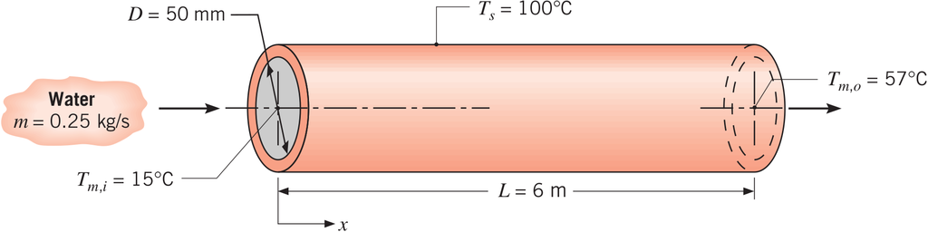

The fluid properties will be evaluated at the average mean temperature. This is given by

$$\bar{T}_m = \frac{T_{mo} + T_{mi}}{2} = 309.1\ \mathrm{K} = 36.0\ \mathrm{°C}$$

Going to Table A.6 at $\bar{T}_m$ shows that the specific heat at constant pressure is

$$c_p = 4.178\ \frac{\mathrm{kJ}}{\left(\mathrm{K} \cdot \mathrm{kg}\right)}$$

Beginning with a surface energy balance for the interface between the fluid and the inside of the pipe shows that for steady state conditions

$$\dot{m} c_p \Delta T_m=q_{conv}=\bar{h} A_s \Delta T_{lm}$$

Solving for the convective coefficient shows

$$\bar{h}=\frac{\dot{m} c_p \Delta T_m}{A_s \Delta T_{lm}}$$

The log mean temperature difference is given by

$$\Delta T_{lm} = \frac{( T_s - T_{m,o}) - ( T_s - T_{m,i})}{\ln ( \frac{T_s - T_{m,o}}{T_s - T_{m,i}})} = 61.6\ \mathrm{K}$$

The surface area $A_s$ is given by

$$A_s = \pi D L = 0.9425\ \mathrm{m}^{2}$$

The convective coefficient is then given by

Answer: $\bar{h} = \frac{\dot{m} c_p (T_{mo} - T_{mi} )}{A_s \Delta T_{lm}} = 755.2\ \frac{\mathrm{W}}{\left(\mathrm{K} \cdot \mathrm{m}^{2}\right)}$